# Heart Disease UCI

### 7. Thal

```
Text(0.5,1,'Thal vs Target based on gender ')
```

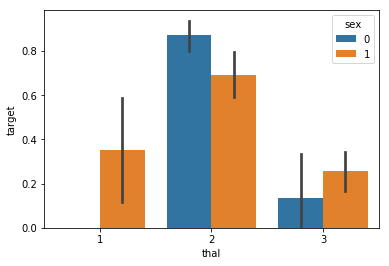

```python
sns.barplot(x = 'thal', y = 'target', hue = 'sex', data=Heart_df)
ax.set_title('Thal vs Target based on gender ')
```

```python
Heart_df.thal.value_counts()
```

```
2    168
3    117
1     18
Name: thal, dtype: int64
```

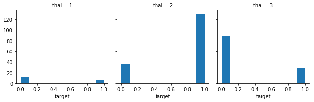

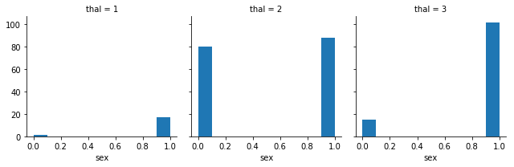

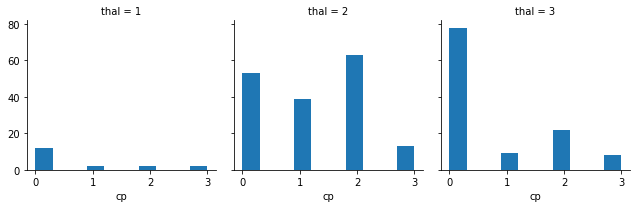

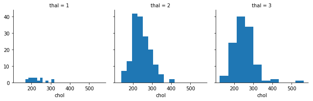

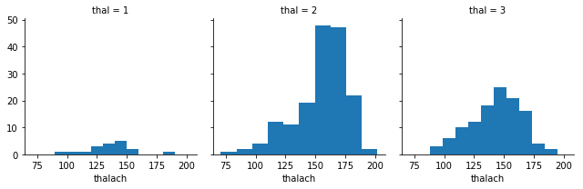

```python
g = sns.FacetGrid(Heart_df, col='thal')
g.map(plt.hist, 'target', bins=10)
g = sns.FacetGrid(Heart_df, col='thal')
g.map(plt.hist, 'sex', bins=10)
g = sns.FacetGrid(Heart_df, col='thal')
g.map(plt.hist, 'cp', bins=10)
g = sns.FacetGrid(Heart_df, col='thal')
g.map(plt.hist, 'chol', bins=10)
g = sns.FacetGrid(Heart_df, col='thal')
g.map(plt.hist, 'thalach', bins=10)
```

```python
#Target 1
a=len(Heart_df[(Heart_df['target']==1)&(Heart_df['thal']==0)])
b=len(Heart_df[(Heart_df['target']==1)&(Heart_df['thal']==1)])
c=len(Heart_df[(Heart_df['target']==1)&(Heart_df['thal']==2)])
d=len(Heart_df[(Heart_df['target']==1)&(Heart_df['thal']==3)])
print('Target 1 Thal 0: ',a)
print('Target 1 Thal 1: ',b)
print('Target 1 Thal 2: ',c)
print('Target 1 Thal 3: ',d)

#so,Apparently, there is a rate at Thal 2.Now, draw graph
print('*'*50)
#Target 0
e=len(Heart_df[(Heart_df['target']==0)&(Heart_df['thal']==0)])
f=len(Heart_df[(Heart_df['target']==0)&(Heart_df['thal']==1)])
g=len(Heart_df[(Heart_df['target']==0)&(Heart_df['thal']==2)])
h=len(Heart_df[(Heart_df['target']==0)&(Heart_df['thal']==3)])
print('Target 0 Thal 0: ',e)
print('Target 0 Thal 1: ',f)
print('Target 0 Thal 2: ',g)
print('Target 0 Thal 3: ',h)
```

```
Target 1 Thal 0:  0
Target 1 Thal 1:  6
Target 1 Thal 2:  131
Target 1 Thal 3:  28
Target 0 Thal 0:  0
Target 0 Thal 1:  12
Target 0 Thal 2:  37
Target 0 Thal 3:  89
```

```
[Text(0,0.5,'Target State and Thal State'),
 Text(0.5,0,'Target State and Thal Counter'),
 Text(0.5,1,'Target VS Thal')]
```

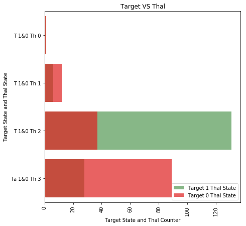

```python
f,ax=plt.subplots(figsize=(7,7))
sns.barplot(y=['T 1&0 Th 0','T 1&0 Th 1','T 1&0 Th 2','Ta 1&0 Th 3'],x=[1,6,131,28],color='green',alpha=0.5,label='Target 1 Thal State')
sns.barplot(y=['T 1&0 Th 0','T 1&0 Th 1','T 1&0 Th 2','Ta 1&0 Th 3'],x=[1,12,37,89],color='red',alpha=0.7,label='Target 0 Thal State')
ax.legend(loc='lower right',frameon=True)
ax.set(xlabel='Target State and Thal Counter',ylabel='Target State and Thal State',title='Target VS Thal')
plt.xticks(rotation=90)
plt.show()
```

### Outliers

```
Text(0.5,1,'Figure 1')
```

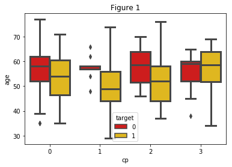

```
Text(0.5,1,'Figure 2')
```

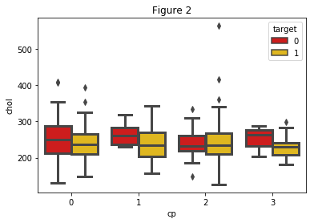

```
Text(0.5,1,'Figure 3')
```

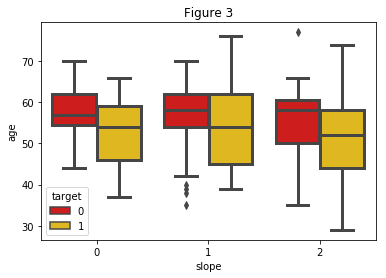

```
Text(0.5,1,'Figure 4')
```

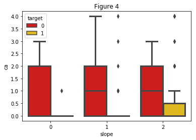

```
Text(0.5,1,'Figure 5')
```

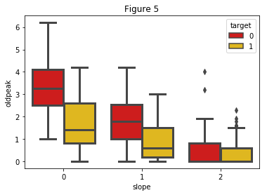

```python
#fig,ax=plt.plot(figsize=(30,8))
#***Categorical Variables: *** Sex, cp, restecg, fbs, slope, exang, thal,  ca<br>
#***Continuos Variables: ***age, trestbps, chol, thalch,oldpeak<br>
#***Predictor Variable: *** target
sns.boxplot(x='cp',y='age',data=Heart_df,hue='target',palette='hot',linewidth=3)
plt.title("Figure 1")
plt.show()

sns.boxplot(x='cp',y='chol',data=Heart_df,hue='target',palette='hot',linewidth=3)
plt.title("Figure 2")
plt.show()

sns.boxplot(x='slope',y='age',data=Heart_df,hue='target',palette='hot',linewidth=3)
plt.title("Figure 3")
plt.show()

sns.boxplot(x='slope',y='ca',data=Heart_df,hue='target',palette='hot',linewidth=3)
plt.title("Figure 4")
plt.show()

sns.boxplot(x='slope',y='oldpeak',data=Heart_df,hue='target',palette='hot',linewidth=3)
plt.title("Figure 5")
plt.show()
```

```python
Heart_df= Heart_df.drop(['bin_chol','bin_thalch','bin_trestbps','bin_oldpeak','AgeRange'],axis=1)
Heart_df.columns
```

```
Index(['age', 'sex', 'cp', 'trestbps', 'chol', 'fbs', 'restecg', 'thalach',
       'exang', 'oldpeak', 'slope', 'ca', 'thal', 'target'],
      dtype='object')
```

We do not see any extreme outliers in the dataset.

- Back to Target
- back to top

### Correlation matrix

```python
#  Lets look at the correlation matrix and plot it using Pandas Style and Matplotlib
Heart_df.corr().round(decimals =2).style.background_gradient(cmap = 'Oranges')
```

|  | age | sex | cp | trestbps | chol | fbs | restecg | thalach | exang | oldpeak | slope | ca | thal | target |
| --- | --- | --- | --- | --- | --- | --- | --- | --- | --- | --- | --- | --- | --- | --- |
| age | 1 | -0.1 | -0.07 | 0.28 | 0.21 | 0.12 | -0.12 | -0.4 | 0.1 | 0.21 | -0.17 | 0.28 | 0.07 | -0.23 |
| sex | -0.1 | 1 | -0.05 | -0.06 | -0.2 | 0.05 | -0.06 | -0.04 | 0.14 | 0.1 | -0.03 | 0.12 | 0.21 | -0.28 |
| cp | -0.07 | -0.05 | 1 | 0.05 | -0.08 | 0.09 | 0.04 | 0.3 | -0.39 | -0.15 | 0.12 | -0.18 | -0.17 | 0.43 |
| trestbps | 0.28 | -0.06 | 0.05 | 1 | 0.12 | 0.18 | -0.11 | -0.05 | 0.07 | 0.19 | -0.12 | 0.1 | 0.06 | -0.14 |
| chol | 0.21 | -0.2 | -0.08 | 0.12 | 1 | 0.01 | -0.15 | -0.01 | 0.07 | 0.05 | -0 | 0.07 | 0.09 | -0.09 |
| fbs | 0.12 | 0.05 | 0.09 | 0.18 | 0.01 | 1 | -0.08 | -0.01 | 0.03 | 0.01 | -0.06 | 0.14 | -0.01 | -0.03 |
| restecg | -0.12 | -0.06 | 0.04 | -0.11 | -0.15 | -0.08 | 1 | 0.04 | -0.07 | -0.06 | 0.09 | -0.07 | -0.01 | 0.14 |
| thalach | -0.4 | -0.04 | 0.3 | -0.05 | -0.01 | -0.01 | 0.04 | 1 | -0.38 | -0.34 | 0.39 | -0.21 | -0.12 | 0.42 |
| exang | 0.1 | 0.14 | -0.39 | 0.07 | 0.07 | 0.03 | -0.07 | -0.38 | 1 | 0.29 | -0.26 | 0.12 | 0.23 | -0.44 |
| oldpeak | 0.21 | 0.1 | -0.15 | 0.19 | 0.05 | 0.01 | -0.06 | -0.34 | 0.29 | 1 | -0.58 | 0.22 | 0.21 | -0.43 |
| slope | -0.17 | -0.03 | 0.12 | -0.12 | -0 | -0.06 | 0.09 | 0.39 | -0.26 | -0.58 | 1 | -0.08 | -0.11 | 0.35 |
| ca | 0.28 | 0.12 | -0.18 | 0.1 | 0.07 | 0.14 | -0.07 | -0.21 | 0.12 | 0.22 | -0.08 | 1 | 0.14 | -0.39 |
| thal | 0.07 | 0.21 | -0.17 | 0.06 | 0.09 | -0.01 | -0.01 | -0.12 | 0.23 | 0.21 | -0.11 | 0.14 | 1 | -0.36 |
| target | -0.23 | -0.28 | 0.43 | -0.14 | -0.09 | -0.03 | 0.14 | 0.42 | -0.44 | -0.43 | 0.35 | -0.39 | -0.36 | 1 |

```
Text(0.5,1,'correlation Heart Disease - FEMALE')
```

```
Text(0.5,1,'correlation Heart Disease - MALE')
```

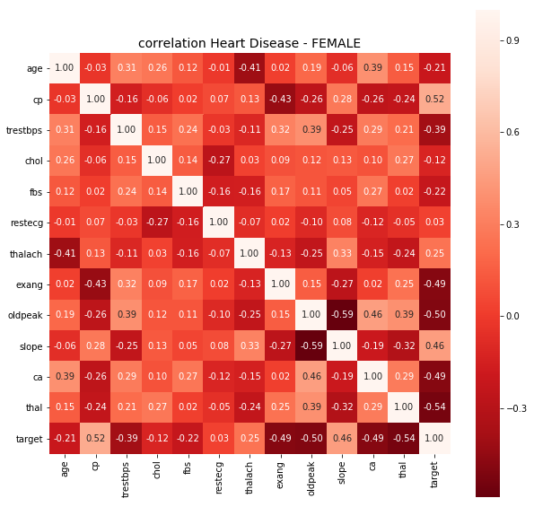

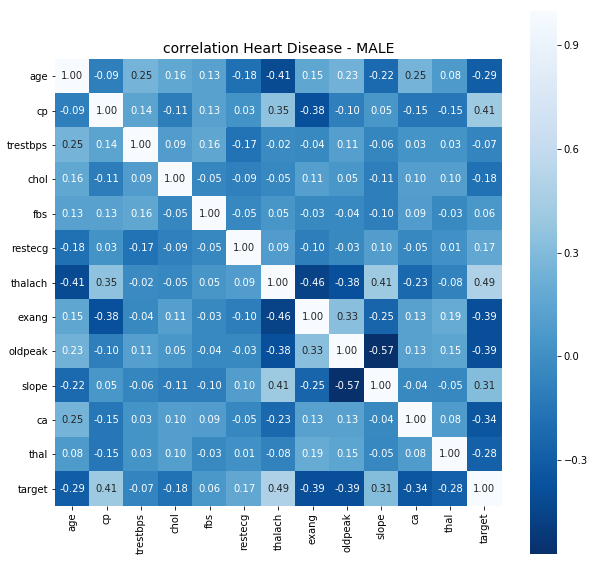

```python
#  Correlation FEMALE - filter dataframe for male/female
dataFemale = Heart_df[(Heart_df['sex'] == 0)]                       # female
dataFemaleCorr = dataFemale.drop(["sex"], axis=1).corr()    # female corr
plt.figure(figsize=(10,10))
plt.title('correlation Heart Disease - FEMALE', fontsize=14)
sns.heatmap(dataFemaleCorr, annot=True, fmt='.2f', square=True, cmap = 'Reds_r')


#  Correlation MALE - filter dataframe for male/female
dataMale   = Heart_df[(Heart_df['sex'] == 1)]                       # male
dataMaleCorr = dataMale.drop(["sex"], axis=1).corr()        # male corr
plt.figure(figsize=(10,10))
plt.title('correlation Heart Disease - MALE', fontsize=14)
sns.heatmap(dataMaleCorr, annot=True, fmt='.2f', square=True, cmap = 'Blues_r')
```

```python
# Corelation with target

x = Heart_df.corr()
pd.DataFrame(x['target']).sort_values(by='target',ascending = False).style.background_gradient(cmap = 'Greens')
print('correlation Heart Disease - MALE')
dataMaleCorr['target'].sort_values(ascending=False)
print('correlation Heart Disease -FEMALE')
dataFemaleCorr['target'].sort_values(ascending=False)
```

|  | target |
| --- | --- |
| target | 1 |
| cp | 0.433798 |
| thalach | 0.421741 |
| slope | 0.345877 |
| restecg | 0.13723 |
| fbs | -0.0280458 |
| chol | -0.0852391 |
| trestbps | -0.144931 |
| age | -0.225439 |
| sex | -0.280937 |
| thal | -0.363322 |
| ca | -0.391724 |
| oldpeak | -0.430696 |
| exang | -0.436757 |

```
correlation Heart Disease - MALE
```

```
target      1.000000
thalach     0.485584
cp          0.407136
slope       0.311255
restecg     0.168234
fbs         0.057675
trestbps   -0.065489
chol       -0.175665
thal       -0.277138
age        -0.290993
ca         -0.339703
oldpeak    -0.393169
exang      -0.393720
Name: target, dtype: float64
```

```
correlation Heart Disease -FEMALE
```

```
target      1.000000
cp          0.522233
slope       0.458207
thalach     0.252103
restecg     0.032553
chol       -0.121769
age        -0.207531
fbs        -0.218218
trestbps   -0.391957
exang      -0.486509
ca         -0.487205
oldpeak    -0.500454
thal       -0.536248
Name: target, dtype: float64
```

- Back to Target
- back to top

# Visualization to Rule Them All

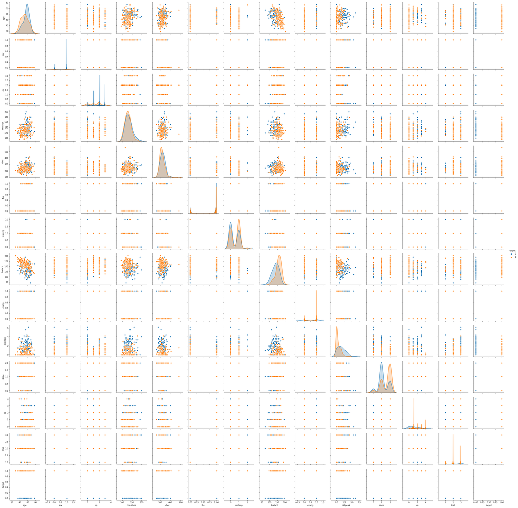

```python
sns.pairplot(Heart_df,hue="target")
plt.show()
```

```python
# Set X as feature data and y as target data

X = Heart_df.drop(['target'],axis =1)
y = Heart_df.target
```

### Chi-Square for Features

```python
from sklearn import feature_selection
chi2, pval = feature_selection.chi2(X,y)
print(chi2)
```

```
[ 23.28662399   7.57683451  62.59809791  14.8239245   23.93639448
   0.20293368   2.97827075 188.32047169  38.91437697  72.64425301
   9.8040952   66.44076512   5.82386062]
```

```python
Heart_df.columns
```

```
Index(['age', 'sex', 'cp', 'trestbps', 'chol', 'fbs', 'restecg', 'thalach',
       'exang', 'oldpeak', 'slope', 'ca', 'thal', 'target'],
      dtype='object')
```

The variables thalach, oldpeak, ca, cp and exang seem to be more influential on the target.

### Feature selection method to check dependency among feature & target

```python
dep = pd.DataFrame(chi2)
dep.columns = ['Dependency']
dep.index = X.columns
dep.sort_values('Dependency', ascending = False).style.background_gradient(cmap = 'terrain')
```

|  | Dependency |
| --- | --- |
| thalach | 188.32 |
| oldpeak | 72.6443 |
| ca | 66.4408 |
| cp | 62.5981 |
| exang | 38.9144 |
| chol | 23.9364 |
| age | 23.2866 |
| trestbps | 14.8239 |
| slope | 9.8041 |
| sex | 7.57683 |
| thal | 5.82386 |
| restecg | 2.97827 |
| fbs | 0.202934 |

Looks like **"fbs"** has lowest effect on target and **"thalach"** has highest

back to top

## Creating the model

```python
#Creating dummy variables for the categorical variables

dummy_restecg = pd.get_dummies(Heart_df['restecg'], prefix='restecg')
Heart_df = Heart_df.join(dummy_restecg)
dummy_cp = pd.get_dummies(Heart_df['cp'], prefix='cp')
Heart_df = Heart_df.join(dummy_cp)
dummy_slope = pd.get_dummies(Heart_df['slope'], prefix='slope')
Heart_df = Heart_df.join(dummy_slope)
dummy_thal = pd.get_dummies(Heart_df['thal'], prefix='thal')
Heart_df = Heart_df.join(dummy_thal)
Heart_df.head()
```

|  | age | sex | cp | trestbps | chol | fbs | restecg | thalach | exang | oldpeak | ... | cp_0 | cp_1 | cp_2 | cp_3 | slope_0 | slope_1 | slope_2 | thal_1 | thal_2 | thal_3 |
| --- | --- | --- | --- | --- | --- | --- | --- | --- | --- | --- | --- | --- | --- | --- | --- | --- | --- | --- | --- | --- | --- |
| 0 | 63 | 1 | 3 | 145 | 233 | 1 | 0 | 150 | 0 | 2.3 | ... | 0 | 0 | 0 | 1 | 1 | 0 | 0 | 1 | 0 | 0 |
| 1 | 37 | 1 | 2 | 130 | 250 | 0 | 1 | 187 | 0 | 3.5 | ... | 0 | 0 | 1 | 0 | 1 | 0 | 0 | 0 | 1 | 0 |
| 2 | 41 | 0 | 1 | 130 | 204 | 0 | 0 | 172 | 0 | 1.4 | ... | 0 | 1 | 0 | 0 | 0 | 0 | 1 | 0 | 1 | 0 |
| 3 | 56 | 1 | 1 | 120 | 236 | 0 | 1 | 178 | 0 | 0.8 | ... | 0 | 1 | 0 | 0 | 0 | 0 | 1 | 0 | 1 | 0 |
| 4 | 57 | 0 | 0 | 120 | 354 | 0 | 1 | 163 | 1 | 0.6 | ... | 1 | 0 | 0 | 0 | 0 | 0 | 1 | 0 | 1 | 0 |

5 rows × 27 columns

```python
# Feature Scaling
from sklearn.preprocessing import StandardScaler
sc_X = StandardScaler()
Heart_df.iloc[:, [0,3,4,7,9]] = sc_X.fit_transform(Heart_df.iloc[:, [0,3,4,7,9]])
Heart_df.head()
```

|  | age | sex | cp | trestbps | chol | fbs | restecg | thalach | exang | oldpeak | ... | cp_0 | cp_1 | cp_2 | cp_3 | slope_0 | slope_1 | slope_2 | thal_1 | thal_2 | thal_3 |
| --- | --- | --- | --- | --- | --- | --- | --- | --- | --- | --- | --- | --- | --- | --- | --- | --- | --- | --- | --- | --- | --- |
| 0 | 0.952197 | 1 | 3 | 0.763956 | -0.256334 | 1 | 0 | 0.015443 | 0 | 1.087338 | ... | 0 | 0 | 0 | 1 | 1 | 0 | 0 | 1 | 0 | 0 |
| 1 | -1.915313 | 1 | 2 | -0.092738 | 0.072199 | 0 | 1 | 1.633471 | 0 | 2.122573 | ... | 0 | 0 | 1 | 0 | 1 | 0 | 0 | 0 | 1 | 0 |
| 2 | -1.474158 | 0 | 1 | -0.092738 | -0.816773 | 0 | 0 | 0.977514 | 0 | 0.310912 | ... | 0 | 1 | 0 | 0 | 0 | 0 | 1 | 0 | 1 | 0 |
| 3 | 0.180175 | 1 | 1 | -0.663867 | -0.198357 | 0 | 1 | 1.239897 | 0 | -0.206705 | ... | 0 | 1 | 0 | 0 | 0 | 0 | 1 | 0 | 1 | 0 |
| 4 | 0.290464 | 0 | 0 | -0.663867 | 2.082050 | 0 | 1 | 0.583939 | 1 | -0.379244 | ... | 1 | 0 | 0 | 0 | 0 | 0 | 1 | 0 | 1 | 0 |

5 rows × 27 columns

### Logistic Regression using stats model

```python
Heart_df.columns
```

```
Index(['age', 'sex', 'cp', 'trestbps', 'chol', 'fbs', 'restecg', 'thalach',
       'exang', 'oldpeak', 'slope', 'ca', 'thal', 'target', 'restecg_0',
       'restecg_1', 'restecg_2', 'cp_0', 'cp_1', 'cp_2', 'cp_3', 'slope_0',
       'slope_1', 'slope_2', 'thal_1', 'thal_2', 'thal_3'],
      dtype='object')
```

```python
#Using stats model for Logistic Regression for all the variables
# Avoid the dummy variable trap by excluding the 0th categorical variable
predictors = [ 'age', 'sex', 'cp_1', 'cp_2', 'cp_3', 'trestbps', 'chol', 'fbs', 'restecg_1', 'restecg_2',
                  'thalach', 'exang', 'oldpeak', 'slope_1', 'slope_2', 'ca', 'thal_1', 'thal_2', 'thal_3']
# Fit the model
m = Logit(Heart_df['target'], Heart_df[predictors])
m = m.fit()
```

```
Optimization terminated successfully.
         Current function value: 0.333968
         Iterations 7
```

### Model Summary

```python
m.summary2()
```

| Model: | Logit | Pseudo R-squared: | 0.515 |
| --- | --- | --- | --- |
| Dependent Variable: | target | AIC: | 240.3845 |
| Date: | 2019-04-12 14:23 | BIC: | 310.9454 |
| No. Observations: | 303 | Log-Likelihood: | -101.19 |
| Df Model: | 18 | LL-Null: | -208.82 |
| Df Residuals: | 284 | LLR p-value: | 8.7363e-36 |
| Converged: | 1.0000 | Scale: | 1.0000 |
| No. Iterations: | 7.0000 |  |  |

|  | Coef. | Std.Err. | z | P>\|z\| | [0.025 | 0.975] |
| --- | --- | --- | --- | --- | --- | --- |
| age | -0.0027 | 0.2142 | -0.0126 | 0.9900 | -0.4225 | 0.4171 |
| sex | -1.5280 | 0.5222 | -2.9263 | 0.0034 | -2.5515 | -0.5046 |
| cp_1 | 1.0032 | 0.5614 | 1.7869 | 0.0739 | -0.0971 | 2.1036 |
| cp_2 | 1.9605 | 0.4782 | 4.0993 | 0.0000 | 1.0231 | 2.8978 |
| cp_3 | 2.0483 | 0.6501 | 3.1509 | 0.0016 | 0.7742 | 3.3225 |
| trestbps | -0.2968 | 0.1868 | -1.5886 | 0.1122 | -0.6629 | 0.0694 |
| chol | -0.2144 | 0.2008 | -1.0679 | 0.2856 | -0.6079 | 0.1791 |
| fbs | 0.0906 | 0.5510 | 0.1645 | 0.8694 | -0.9893 | 1.1706 |
| restecg_1 | 0.5545 | 0.3735 | 1.4846 | 0.1376 | -0.1775 | 1.2865 |
| restecg_2 | -0.2711 | 2.2617 | -0.1199 | 0.9046 | -4.7039 | 4.1616 |
| thalach | 0.3931 | 0.2470 | 1.5910 | 0.1116 | -0.0911 | 0.8772 |
| exang | -0.7846 | 0.4245 | -1.8482 | 0.0646 | -1.6167 | 0.0475 |
| oldpeak | -0.5658 | 0.2613 | -2.1651 | 0.0304 | -1.0781 | -0.0536 |
| slope_1 | -0.7447 | 0.8610 | -0.8649 | 0.3871 | -2.4323 | 0.9429 |
| slope_2 | 0.1917 | 0.9365 | 0.2047 | 0.8378 | -1.6439 | 2.0273 |
| ca | -0.8203 | 0.2032 | -4.0371 | 0.0001 | -1.2186 | -0.4221 |
| thal_1 | 1.6879 | 1.1511 | 1.4664 | 0.1425 | -0.5682 | 3.9440 |
| thal_2 | 1.6666 | 0.9445 | 1.7645 | 0.0776 | -0.1846 | 3.5179 |
| thal_3 | 0.3198 | 1.0084 | 0.3171 | 0.7512 | -1.6567 | 2.2963 |

### Confusion Matrix

```python
conf_mat = m.pred_table()

tn, fp, fn, tp = conf_mat.flatten()
print ('True Positive :', tp)
print ('False Negative:', fn)
print ('False Positive:', fp)
print ('True Negative :', tn)

acc = (tp + tn) / np.sum(conf_mat)
print ("Accuracy of the model is: %1.2f" % acc)

prc = tp / (tp + fp)
rec = tp / (tp + fn)
print ("Model's precision is %1.2f and it's recall is %1.2f" % (prc, rec))

mcc = (tp * tn - fp * fn)/np.sqrt((tp + fp)*(tp + fn)*(tn + fp)*(tn + fn))
print ("Mathews correlation coefficient between the estimates and the true response is: %1.2f" % mcc)
```

```
True Positive : 150.0
False Negative: 15.0
False Positive: 27.0
True Negative : 111.0
Accuracy of the model is: 0.86
Model's precision is 0.85 and it's recall is 0.91
Mathews correlation coefficient between the estimates and the true response is: 0.72
```

```python
#Adding the probability for each record from the model
Heart_df.loc[:, 'p'] = m.predict(Heart_df[predictors])
```

```
Text(0.5,0,'logit(p)')
```

```
Text(0,0.5,'p')
```

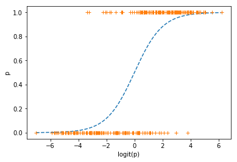

```python
##Plotting the model probability output
Heart_df = Heart_df.sort_values(by = ['p'], axis = 0)
plt.plot(logit(Heart_df.p), Heart_df.p, '--')
plt.plot(logit(Heart_df.p), Heart_df.target, '+')
plt.xlabel('logit(p)')
plt.ylabel('p')
plt.show()
```

```python
# Set discrimination thresholds
ths = np.arange(0., 1.0, 0.025)
#th = 0
# Containers
sensitivity = []
specificity = []
accuracy = []
matthews = []

old_settings = np.seterr(all='ignore')  #seterr to known value
np.seterr(divide='ignore')
# Main loop
for th in ths:
    # Generate estimates
    conf_mat = m.pred_table(threshold=th)
    # Extract TN, FP, ...
    tn, fp, fn, tp = conf_mat.flatten()

    # Calculate sensitivity and specificity
    sens = (1. * tp) / (tp + fn)
    spec = (1. * tn) / (tn + fp)

    # Calculate ACC and MCC
    acc = (tp + tn) / np.sum(conf_mat)
    mcc = (tp * tn - fp * fn) / np.sqrt((tp + fp)*(tp + fn)*(tn + fp)*(tn + fn))

    # Add to containers
    sensitivity.append(sens)
    specificity.append(spec)
    accuracy.append(acc)
    if np.isnan(mcc) == True:
        mcc = 0
    matthews.append(mcc)
```

```
{'divide': 'ignore', 'over': 'ignore', 'under': 'ignore', 'invalid': 'ignore'}
```

```python
# Bind all the numbers together
roc = pd.DataFrame({'discret_thr' : ths,
                    'sensitivity' : sensitivity,
                    'specificity' : specificity,
                    '_specificity' : [1 - x for x in specificity],
                    'accuracy' : accuracy,
                    'matthews' : matthews})

# Sort by 1 - specificity so we can plot it easily
roc = roc.sort_values(by = "_specificity")
roc.head()
```

|  | discret_thr | sensitivity | specificity | _specificity | accuracy | matthews |
| --- | --- | --- | --- | --- | --- | --- |
| 39 | 0.975 | 0.212121 | 0.992754 | 0.007246 | 0.567657 | 0.315329 |
| 38 | 0.950 | 0.351515 | 0.985507 | 0.014493 | 0.640264 | 0.421174 |
| 37 | 0.925 | 0.436364 | 0.985507 | 0.014493 | 0.686469 | 0.489021 |
| 36 | 0.900 | 0.503030 | 0.978261 | 0.021739 | 0.719472 | 0.531631 |
| 35 | 0.875 | 0.533333 | 0.971014 | 0.028986 | 0.732673 | 0.546231 |

### Plotting the ROC curve

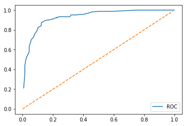

```python
plt.plot(roc._specificity, roc.sensitivity, label = 'ROC')
plt.plot(np.arange(0., 1., 0.01),
         np.arange(0., 1., 0.01),
         '--')

plt.legend(loc = 4)
```

```python
auc = np.trapz(y = roc.sensitivity, x = roc._specificity)
print ("Area under ROC curve = %1.2f" % auc)
```

```
Area under ROC curve = 0.93
```

```python
predictors_mod = [ 'sex', 'cp', 'trestbps', 'restecg',
                 'thalach', 'exang', 'oldpeak', 'slope', 'ca', 'thal']

# Fit the model
m_mod = Logit(Heart_df['target'], Heart_df[predictors_mod])
m_mod = m_mod.fit()
```

```
Optimization terminated successfully.
         Current function value: 0.363086
         Iterations 7
```

```python
m_mod.summary2()
```

| Model: | Logit | Pseudo R-squared: | 0.473 |
| --- | --- | --- | --- |
| Dependent Variable: | target | AIC: | 240.0302 |
| Date: | 2019-04-12 14:46 | BIC: | 277.1675 |
| No. Observations: | 303 | Log-Likelihood: | -110.02 |
| Df Model: | 9 | LL-Null: | -208.82 |
| Df Residuals: | 293 | LLR p-value: | 1.0509e-37 |
| Converged: | 1.0000 | Scale: | 1.0000 |
| No. Iterations: | 7.0000 |  |  |

|  | Coef. | Std.Err. | z | P>\|z\| | [0.025 | 0.975] |
| --- | --- | --- | --- | --- | --- | --- |
| sex | -1.3243 | 0.4088 | -3.2398 | 0.0012 | -2.1255 | -0.5232 |
| cp | 1.0111 | 0.1776 | 5.6920 | 0.0000 | 0.6630 | 1.3593 |
| trestbps | -0.3696 | 0.1775 | -2.0829 | 0.0373 | -0.7174 | -0.0218 |
| restecg | 0.7140 | 0.3305 | 2.1601 | 0.0308 | 0.0662 | 1.3618 |
| thalach | 0.4378 | 0.2090 | 2.0951 | 0.0362 | 0.0282 | 0.8474 |
| exang | -0.7044 | 0.3989 | -1.7659 | 0.0774 | -1.4862 | 0.0774 |
| oldpeak | -0.5761 | 0.2422 | -2.3785 | 0.0174 | -1.0509 | -0.1014 |
| slope | 1.0279 | 0.3003 | 3.4224 | 0.0006 | 0.4392 | 1.6166 |
| ca | -0.7704 | 0.1866 | -4.1290 | 0.0000 | -1.1361 | -0.4047 |
| thal | -0.4581 | 0.2125 | -2.1556 | 0.0311 | -0.8746 | -0.0416 |

```python
conf_mat_mod = m_mod.pred_table()
tn, fp, fn, tp = conf_mat_mod.flatten()

print ('True Positive :', tp)
print ('False Negative:', fn)
print ('False Positive:', fp)
print ('True Negative :', tn)

acc = (tp + tn) / np.sum(conf_mat_mod)
print ("Accuracy of the model is: %1.2f" % acc)

prc = tp / (tp + fp)
rec = tp / (tp + fn)
print ("Model's precision is %1.2f and it's recall is %1.2f" % (prc, rec))
```

```
True Positive : 148.0
False Negative: 17.0
False Positive: 25.0
True Negative : 113.0
Accuracy of the model is: 0.86
Model's precision is 0.86 and it's recall is 0.90
```

back to top

### Logistic Model using sklearn

```python
Heart_df.columns
```

```
Index(['age', 'sex', 'cp', 'trestbps', 'chol', 'fbs', 'restecg', 'thalach',
       'exang', 'oldpeak', 'slope', 'ca', 'thal', 'target', 'restecg_0',
       'restecg_1', 'restecg_2', 'cp_0', 'cp_1', 'cp_2', 'cp_3', 'slope_0',
       'slope_1', 'slope_2', 'thal_1', 'thal_2', 'thal_3', 'p'],
      dtype='object')
```

```python
#Logistic Regression using sklearn
#Splitting data into train and test dataset(70-30)
X1 = Heart_df.iloc[:, [0,1,3,4,5,7,8,9,11,15,16,18,19,20,22,23,25,26]].values
Y1 = Heart_df.iloc[:, 13].values
X1_Train, X1_Test, Y1_Train, Y1_Test = train_test_split(X1, Y1, test_size = 0.3, random_state = 101)
```

```python
# Fitting the Logistic Regression into the Training set
#from sklearn.linear_model import LogisticRegression
classifier1 = LogisticRegression(random_state = 0)
classifier1.fit(X1_Train, Y1_Train)
print('Intercept: ',classifier1.intercept_)
print('Coefficients: ', classifier1.coef_)
```

```
LogisticRegression(C=1.0, class_weight=None, dual=False, fit_intercept=True,
          intercept_scaling=1, max_iter=100, multi_class='ovr', n_jobs=1,
          penalty='l2', random_state=0, solver='liblinear', tol=0.0001,
          verbose=0, warm_start=False)
```

```
Intercept:  [0.76564485]
Coefficients:  [[ 0.00547855 -0.88260868 -0.08076047  0.04575704  0.20991688  0.10768912
  -0.83166965 -0.67438769 -0.65705342  0.54486856  0.04931855  0.59338078
   1.54370187  1.12475128 -0.55489393  0.49749489  0.47434572 -1.07943183]]
```

```python
print("Logistic Train accuracy: ",classifier1.score(X1_Train,Y1_Train))
print("Logistic Test accuracy: ", classifier1.score(X1_Test,Y1_Test))
```

```
Logistic Train accuracy:  0.8584905660377359
Logistic Test accuracy:  0.8681318681318682
```

### Confusion Matrix

```
array([[32,  8],
       [ 4, 47]], dtype=int64)
```

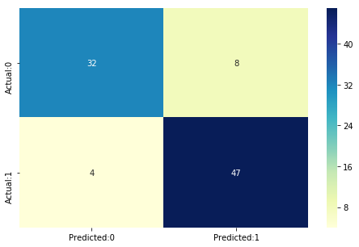

```python
Y1_Pred = classifier1.predict(X1_Test)
from sklearn.metrics import confusion_matrix
cm1 = confusion_matrix(Y1_Test, Y1_Pred)
cm1
conf_matrix=pd.DataFrame(data=cm1,columns=['Predicted:0','Predicted:1'],index=['Actual:0','Actual:1'])
plt.figure(figsize = (8,5))
sns.heatmap(conf_matrix, annot=True,fmt='d',cmap="YlGnBu")
```

### Classification report

```python
from sklearn.metrics import classification_report
target_names = ['Heart Disease', 'No Heart Disease']
print(classification_report(Y1_Test, Y1_Pred, target_names=target_names))
```

```
                  precision    recall  f1-score   support

   Heart Disease       0.89      0.80      0.84        40
No Heart Disease       0.85      0.92      0.89        51

     avg / total       0.87      0.87      0.87        91
```

### ROC Curve

```
(0.0, 1.0)
```

```
(0.0, 1.05)
```

```
Text(0.5,0,'False Positive Rate')
```

```
Text(0,0.5,'True Positive Rate')
```

```
Text(0.5,1,'Receiver operating characteristic')
```

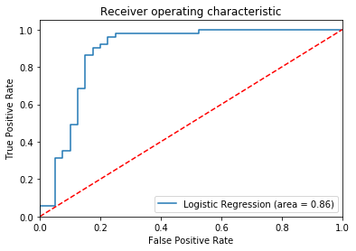

```python
from sklearn.metrics import roc_auc_score
from sklearn.metrics import roc_curve
logit_roc_auc = roc_auc_score(Y1_Test, classifier1.predict(X1_Test))
fpr, tpr, thresholds = roc_curve(Y1_Test, classifier1.predict_proba(X1_Test)[:,1])
plt.figure()
plt.plot(fpr, tpr, label='Logistic Regression (area = %0.2f)' % logit_roc_auc)
plt.plot([0, 1], [0, 1],'r--')
plt.xlim([0.0, 1.0])
plt.ylim([0.0, 1.05])
plt.xlabel('False Positive Rate')
plt.ylabel('True Positive Rate')
plt.title('Receiver operating characteristic')
plt.legend(loc="lower right")
plt.savefig('Log_ROC')
plt.show()
```

```python
#sklearn.metrics.roc_auc_score(y_test,y_pred_prob_yes[:,1])
from sklearn import metrics
print("Area under Curve = ", metrics.roc_auc_score(Y1_Test, Y1_Pred))
```

```
Area under Curve =  0.8607843137254901
```

back to top

### Naive Bayes Model

```python
#Naive Bayes Modelling using scales variables only, no dummy variables
#Splitting data into train and test dataset(70-30)
X = Heart_df.iloc[:, 0:13].values
Y = Heart_df.iloc[:, 13].values
X_Train, X_Test, Y_Train, Y_Test = train_test_split(X, Y, test_size = 0.3, random_state = 101)
```

```python
clf = GaussianNB()
# Test options and evaluation metric
scoring = 'accuracy'

#Fitting the training set for the gaussian classifier
clf.fit(X_Train, Y_Train)

#calling the cross validation function
cv_results = model_selection.cross_val_score(clf, X_Train, Y_Train, scoring=scoring)

#Model Performance
#displaying the mean and standard deviation of the prediction
msg = "%s: %f (%f)" % ('NB model accuracy', cv_results.mean(), cv_results.std())
print(msg)

#Predicting for the Test(Validation) Set
pred_clf = clf.predict(X_Test)

print("NB test Accuracy :", clf.score(X_Test, Y_Test))
```

```
GaussianNB(priors=None)
```

```
NB model accuracy: 0.806439 (0.037940)
NB test Accuracy : 0.8571428571428571
```

### Confusion Matrix

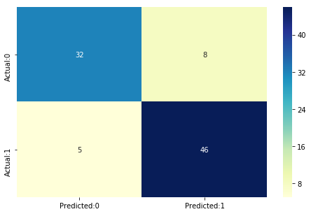

```python
cm = metrics.confusion_matrix(Y_Test, pred_clf)
conf_matrix = pd.DataFrame(data=cm,columns=['Predicted:0','Predicted:1'],index=['Actual:0','Actual:1'])
plt.figure(figsize = (8,5))
sns.heatmap(conf_matrix, annot=True,fmt='d',cmap="YlGnBu")
```

### Classification report

```python
target_names = ['Heart Disease', 'No Heart Disease']
print(classification_report(Y_Test, pred_clf, target_names=target_names))
```

```
                  precision    recall  f1-score   support

   Heart Disease       0.86      0.80      0.83        40
No Heart Disease       0.85      0.90      0.88        51

     avg / total       0.86      0.86      0.86        91
```

back to top

### ROC curve

```
(0.0, 1.0)
```

```
(0.0, 1.05)
```

```
Text(0.5,0,'False Positive Rate')
```

```
Text(0,0.5,'True Positive Rate')
```

```
Text(0.5,1,'Receiver operating characteristic')
```

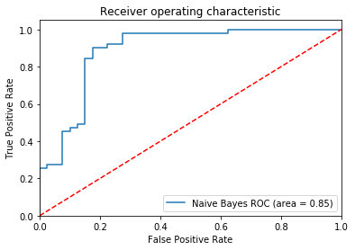

```python
roc_auc = roc_auc_score(Y_Test, clf.predict(X_Test))
fpr2, tpr2, thresholds2 = roc_curve(Y_Test, clf.predict_proba(X_Test)[:,1])
plt.figure()
plt.plot(fpr2, tpr2, label='Naive Bayes ROC (area = %0.2f)' % roc_auc)
plt.plot([0, 1], [0, 1],'r--')
plt.xlim([0.0, 1.0])
plt.ylim([0.0, 1.05])
plt.xlabel('False Positive Rate')
plt.ylabel('True Positive Rate')
plt.title('Receiver operating characteristic')
plt.legend(loc="lower right")
plt.savefig('Log_ROC')
plt.show()
```

```python
#sklearn.metrics.roc_auc_score(y_test,y_pred_prob_yes[:,1])
metrics.roc_auc_score(Y_Test, pred_clf)
```

```
0.8509803921568627
```

back to top

### Summary

The dataset has no null values. Based on our analysis we did not drop any variables.

There were not any outliers in the dataset. There were 2 records having missing values for thal variable which we replaced with the value of records having similar values for other columns.

We have a balanced dataset with 45% cases with heart disease and 55% without heart disease. Men are more prone to heart disease than women.

The age range is 29-77 yrs in the sample. We see that the age group 55-60yrs among males and the age group 55-65yrs among women has the most heart disease patients.

For men with heart disease the maximum heart rate(thalach) achieved lies in the range 100-175 and without heart disease is from 140-190. For women with heart disease the maximum heart rate achieved lies in the range 130-170 and without heart disease is from 150-180. the maximum heart rate achieved decreases as age increases.

All types of chest pain can be cause of heart problem but Patients with asymptomatic chest pain are more common with heart disease. Exang (exercise induced angina) is a good indicator of heart disease. The chances of heart disease increases as the no. of blocked blood vessel (ca) increase. The slope of the heart beat should be up-sloping, it being flat or down sloping indicates heart problems. Abnormal resting ecg results is a indicator of heart problem. Patients with healthy heart have old peak value of 0 mostly. The variables chol, fbs,trestbps values seem in similar range for cases with heart or without heart disease.

We are not applying Linear Regression since the target variable is binary. For Logistic regression and Naive Bayes model, the model results are as follows:

[output not shown]

From the above table we see that the test accuracy, Heart Disease precision, AUC is slightly higher for Logistic Regression.

From the feature importance, the variables thalach, oldpeak, ca, cp and exang seem to be more influential on the target.

So basically patients having lower values for maximum heart rate achieved, oldpeak > 0, ca > 0, asymptomatic chest pain and having exercise induced angina are more likely having heart disease. Also men are more prone to heart disease than females.

back to top